# Questionnaire Report for San Francisco Bay herring

## Selectivity of large fish

| Answered |
| --- |
| Asymptotic selectivity (SL = 1) |
| Declining selectivity with length (0.75 < SL < 1) |
| Dome-shaped selectivity (0.25 < SL < 0.75) |
| Strong dome-shaped selectivity (SL < 0.25) |

Justification

Small mesh gill nets likely avoid larger fish - they have disappeared from the catch in recent years (which may either be due to depletion or changes in gear. However, older assessments (https://oac.cdlib.org/view?docId=kt3199n5xp&brand=oac4&doc.view=entire_text) indicate only selectivity for larger fish with no indication of dome-shape (though not much evidence either way)

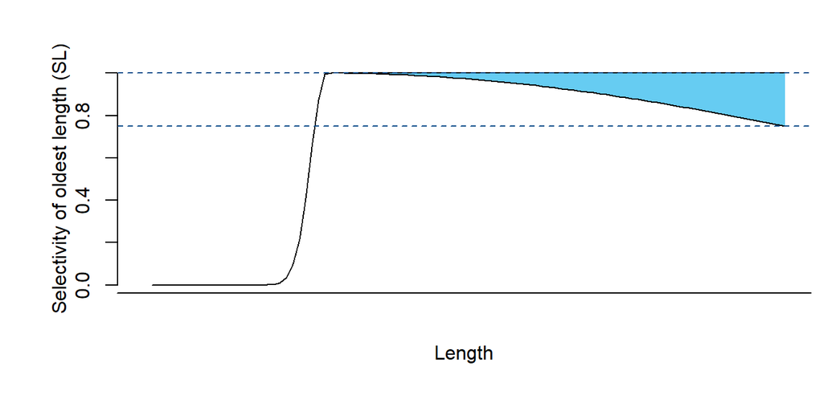

## Discard rate

| Answered |
| --- |
| Low (DR < 1%) |
| Low - moderate (1% < DR < 10%) |
| Moderate (10% < DR < 30%) |
| Moderate - high (30% < DR < 50%) |
| High (50% < DR < 70%) |

Justification

“There is no bait used for the gillnet fishery. Because bycatch rates are negligible for the sac roe and fresh fish fishery (<1%), it is safe to assume that the ratio of discards to total landings is less than 20%.” (Seafood Watch Herring-Pacific-California.pdf) - ‘Bycatch’ here refers to non-target species  
I would presume this does not account for escapes from the nets, which would elevate discards of injured fish (hence raising to 10%)

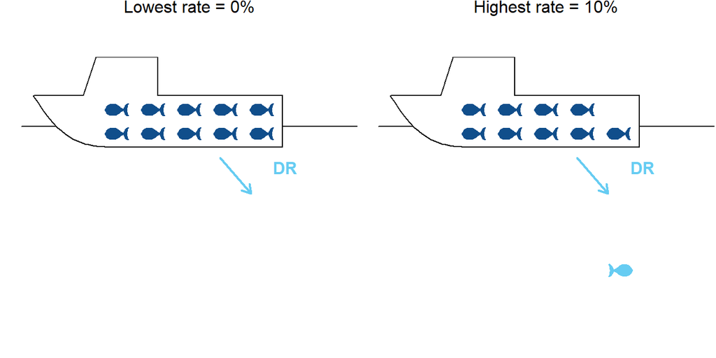

## Post-release mortality rate

| Answered |
| --- |
| Low (PRM < 5%) |
| Low - moderate (5% < PRM < 25%) |
| Moderate (25% < PRM < 50%) |
| Moderate - high (50% < PRM < 75%) |
| High (75% < PRM < 95%) |
| Almost all die (95% < PRM < 100%) |

[output not shown]

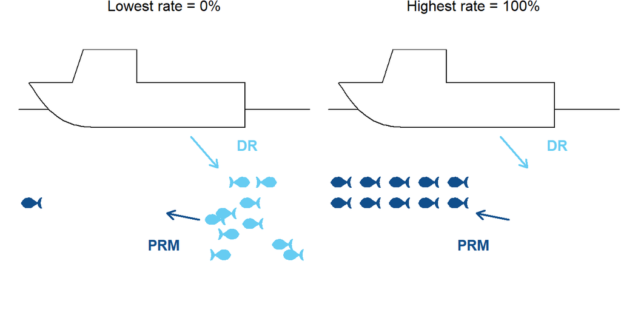

## Recruitment variability

| Answered |
| --- |
| Very low (less than 20% inter-annual changes (IAC)) |
| Low (max IAC of between 20% and 60%) |
| Moderate (max IAC of between 60% and 120%) |
| High (max IAC of between 120% and 180%) |
| Very high (max IAC greater than 180%) |

Justification

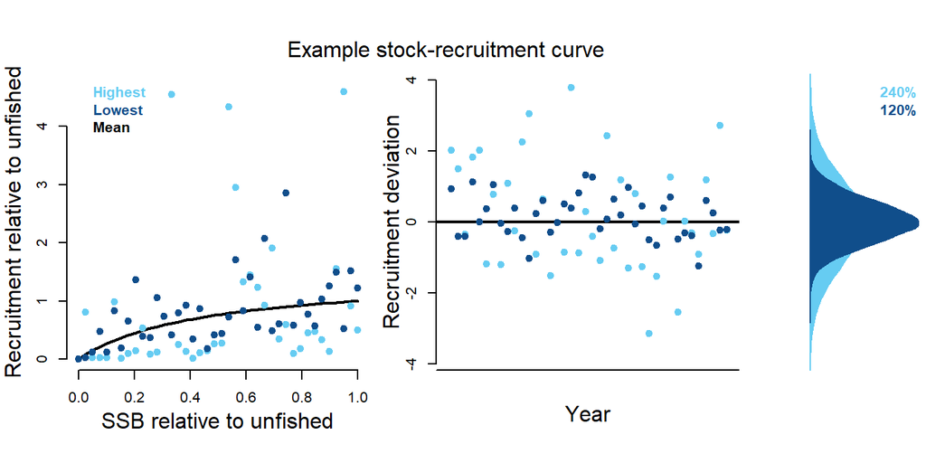

## Size of an existing MPA

| Answered |
| --- |
| None |
| Small (A < 5%) |
| Small-moderate (5% < A < 10%) |
| Moderate (10% < A < 20%) |
| Large (20% < A < 30%) |
| Very large (30% < A < 40%) |
| Huge (40% < A < 50%) |

[output not shown]

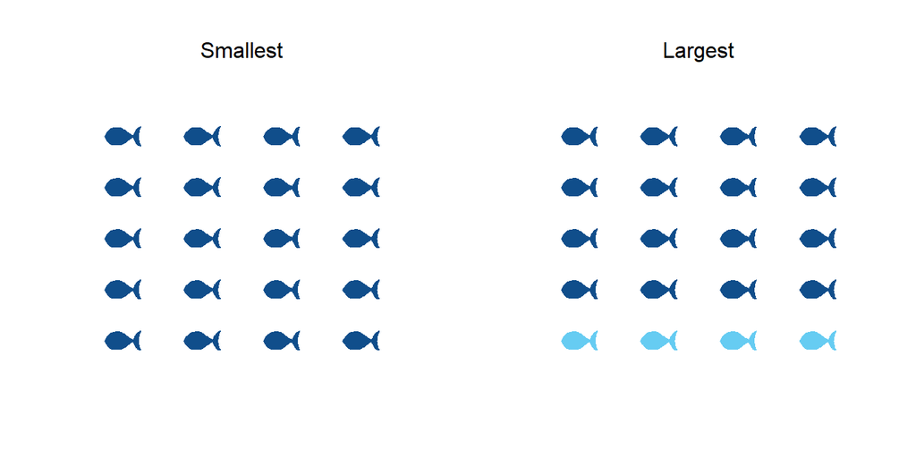

## Spatial mixing (movement) in/out of existing MPA

| Answered |
| --- |
| Very low (P < 1%) |
| Low (1% < P < 5%) |
| Moderate (5% < P < 10%) |
| High (10% < P < 20%) |
| Fully mixed |

[output not shown]

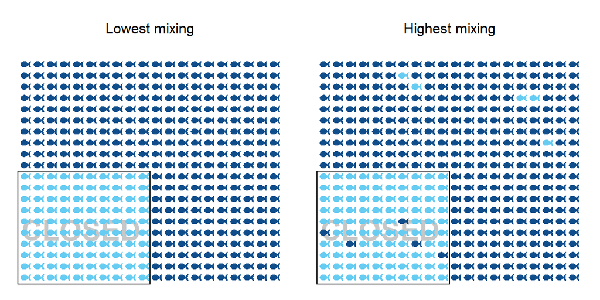

## Size of a future potential MPA

| Answered |
| --- |
| None |
| Small (A < 5%) |
| Small-moderate (5% < A < 10%) |
| Moderate (10% < A < 20%) |
| Large (20% < A < 30%) |
| Very large (30% < A < 40%) |
| Huge (40% < A < 50%) |

| Justification |
| --- |
| No changes anticipated |

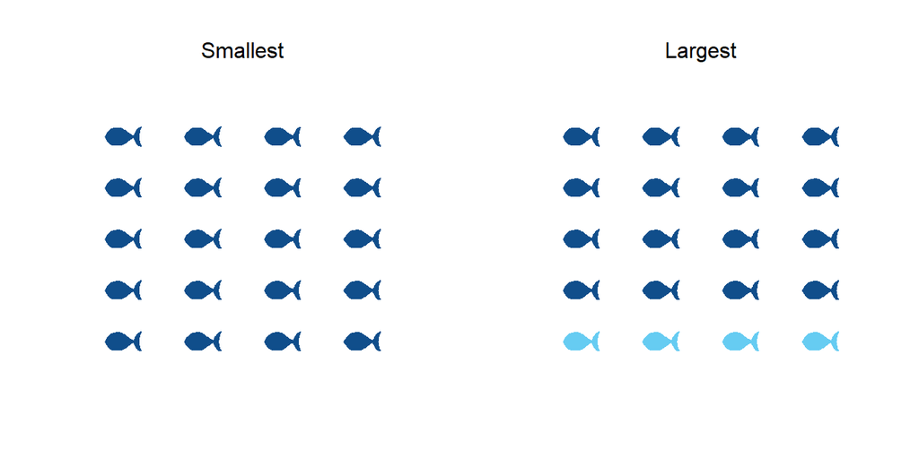

## Spatial mixing (movement) in/out of future potential MPA

| Answered |
| --- |
| Very low (P < 1%) |
| Low (1% < P < 5%) |
| Moderate (5% < P < 10%) |
| High (10% < P < 20%) |
| Fully mixed |

| Justification |
| --- |
| Same as above - movement during spawning season will be limited. |

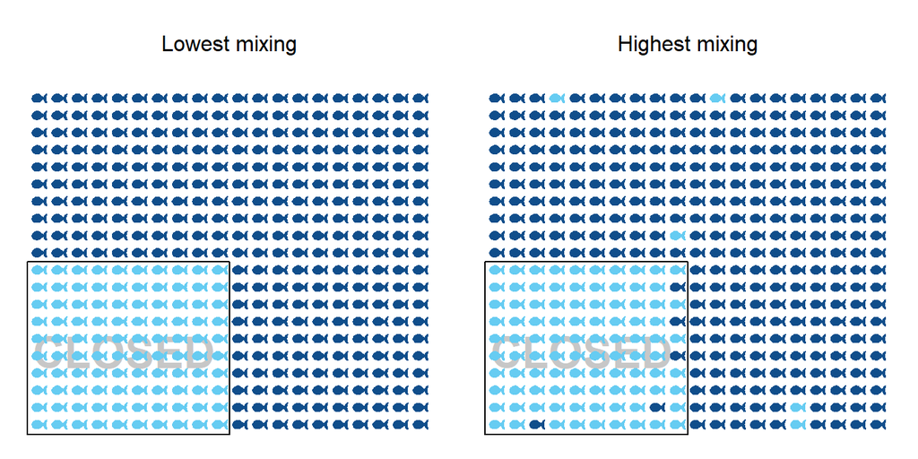

## Initial stock depletion

| Answered |
| --- |
| Very low (0.1 < D1 < 0.15) |
| Low (0.15 < D1 < 0.3) |
| Moderate (0.3 < D < 0.5) |
| High (0.5 < D1) |
| Asymptotic unfished levels (D1 = 1) |

| Justification |
| --- |
| The fishery is certainly not unfished at the start of the time-series I could find (1916 and on). However, the level of fishing in early years (1880s-1916) is unknown. |

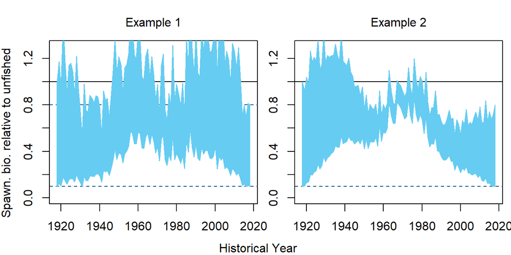

# Management Characteristics

## Types of fishery management that are possible

| Answered |
| --- |
| TAC (Total Allowable Catch): a catch limit |
| TAE (Total Allowable Effort): an effort limit |
| Size limit |
| Time-area closures (a marine reserve) |

Justification

1. Describe what, if any, current management measures are used to constrain catch/effort.  
Fishery is focussed on spawning herring. Herring may be caught Dec 1-March 31 (HEOK fishery) or Jan 1-March 15 (gill net fishery). There are measures to constrain fishing days (which days of the season you may fish based on your license number); closed areas. Commercial fishers must have a license. Recreational fishery is essentially unlimited but relatively low.  
“The fishery is also managed by seasonal closures that are set every year, gear restrictions such as a minimum mesh size of 2 inches, and a limited entry (LE) permit system. The fishery is only open in state waters; open ocean fishing was prohibited in 2009.”; “Additionally tools such as port sampling, landing receipts, logbooks, and observer coverage are used to monitor catch and ensure vessels have the correct permits for the catch they are landing. Violators are prosecuted under the law. There is no evidence of systemic non- compliance.” (Rapid Assessment Pacific Herring.pdf)  
“  
2. Describe historical management measures, if any.  
The fishery has been managed using a quota set based on survey biomass.  
”DFW has managed the commercial Pacific herring sac-roe fishery in San Francisco Bay since the opening in 1972. DFW’s biological and enforcement staff have worked closely with the fishing industry throughout this period to provide for a sustainable and orderly fishery. This has been achieved through annual population assessments, California Environmental Quality Act review, evolving regulatory changes (fishery regulations) and oversight by the FGC.  
The FGC has regulatory responsibility for management of this fishery with DFW providing recommendations and managing the fishery directly." (Rapid Assessment Pacific Herring.pdf  
“Quotas are the principal regulatory tool used to establish adequate protection of herring as an important forage species and to provide for the long-term yield of the commercial fishery. Each year, the Department recommends a harvest percentage that is not determined by a fixed mathematical formula; rather, the recommendation is based upon modeling results and takes into account additional data collected each season, such as ocean productivity and bay conditions, growth rates of herring, strength of individual year- classes, and predicted size of incoming year-classes (i.e., recruitment). In response to poor recruitment, indication of population stress, and/or unfavorable oceanographic conditions, harvest percentages beginning in 2003 have been set at or below 10 percent. Since the 2003-04 season, harvest percentages on average have allowed over 90 percent of the spawning biomass to return to the ocean after spawning in the bay. The Department and DHAC recommended a no fishery option (zero ton quota) for the 2009-10 season, when the herring spawning biomass in 2008-09 fell to a new low of 4,833 tons. The Commission adopted this recommendation and the commercial fishery was closed in San Francisco Bay for the 2009-10 season. Since the re-opening of the fishery for the 2010-11 season, the Department has recommended harvest percentages at five percent or less of the spawning biomass. Based on accepted fishery management principles these harvest percentages are conservative and represent a precautionary approach to safeguard the population as forage and to provide a robust reproductive base to allow for stock rebuilding.” (https://nrm.dfg.ca.gov/FileHandler.ashx?DocumentID=148632&inline)  
3. Describe main strengths and weaknesses of current monitoring and enforcement capacity.  
Monitoring is relatively high, though no on-board observers.  
4. Describe and reference any legal/policy requirements for management, monitoring and enforcement.  
references above

## TAC offset: consistent overages/underages

| Answered |
| --- |
| Large underages (40% - 70% of recommended) |
| Underages (70% - 90% of recommended) |
| Slight underages (90% - 100% of recommended) |
| Taken exactly (95% - 105% of recommended) |
| Slight overages (100% - 110% of recommended) |
| Overages (110% - 150% of recommended) |
| Large overages (150% - 200% of recommended) |

| Justification |
| --- |
| Fishery season is set, so overages do occur. Recent years has seen close adherence to quota after consistent underages in early 2000s (see Quota.pdf) |

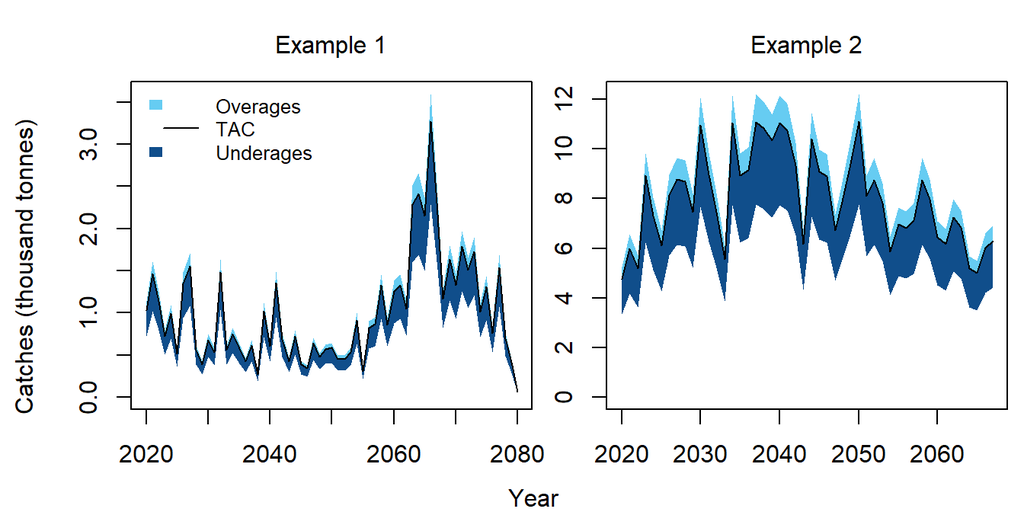

## TAC implementation variability

| Answered |
| --- |
| Constant (V < 1%) |
| Not variable (1% < V < 5%) |
| Low variability (5% < V < 10%) |
| Variable (10% < V < 20%) |
| Highly variable (20% < V < 40%) |

[output not shown]

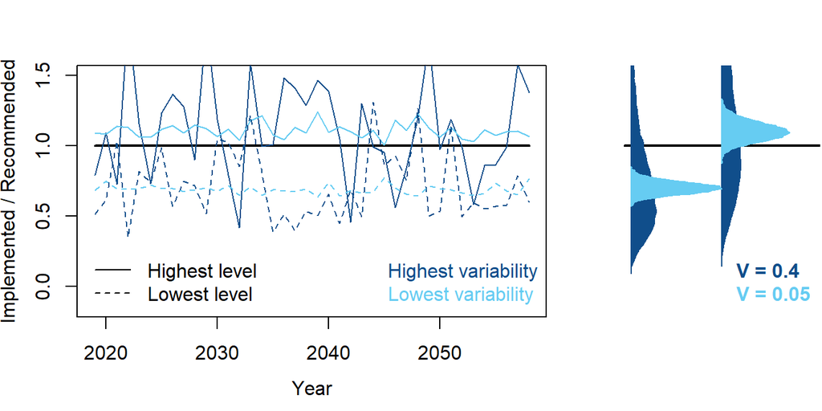

## TAE offset: consistent overages/underages

| Answered |
| --- |
| Large underages (40% - 70% of recommended) |
| Underages (70% - 90% of recommended) |
| Slight underages (90% - 100% of recommended) |
| Taken exactly (95% - 105% of recommended) |
| Slight overages (100% - 110% of recommended) |
| Overages (110% - 150% of recommended) |
| Large overages (150% - 200% of recommended) |

| Justification |
| --- |
| TAE is in the form of ‘limited entry’, but I do not perveive that they have limited entry in quite a while. Effort actually went down recently as price dropped. |

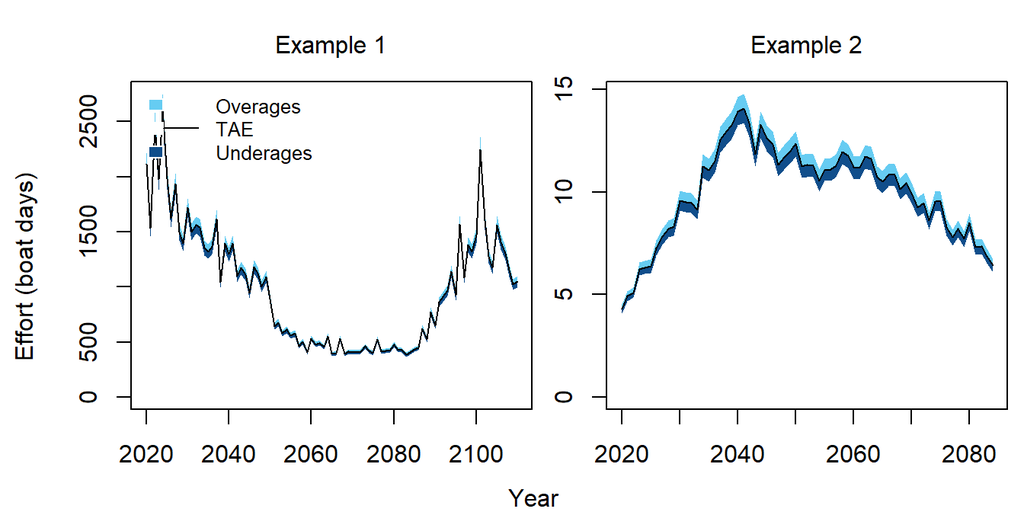

## TAE implementation variability

| Answered |
| --- |
| Constant (V < 1%) |
| Not variable (1% < V < 5%) |
| Low variability (5% < V < 10%) |
| Variable (10% < V < 20%) |
| Highly variable (20% < V < 40%) |

| Justification |
| --- |
| Effort really only varies based on license purchases |

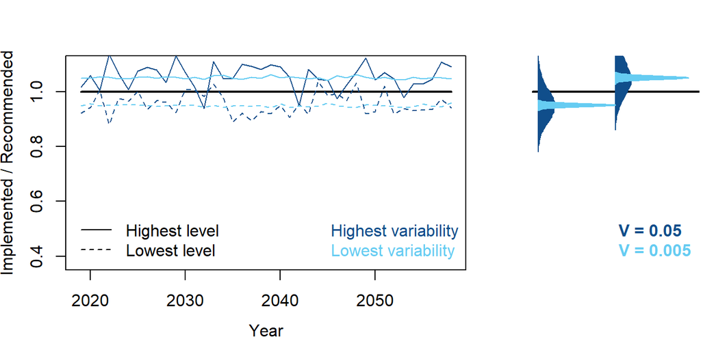

## Size limit offset: consistent overages/underages

| Answered |
| --- |
| Much smaller (40% - 70% of recommended) |
| Smaller (70% - 90% of recommended) |
| Slightly smaller (90% - 100% of recommended) |
| Taken exactly (95% - 105% of recommended) |
| Slightly larger (100% - 110% of recommended) |
| Larger (110% - 150% of recommended) |
| Much larger (150% - 200% of recommended) |

| Justification |
| --- |
| No minimum size, just restrictions on minimum mesh size in gill net fishery |

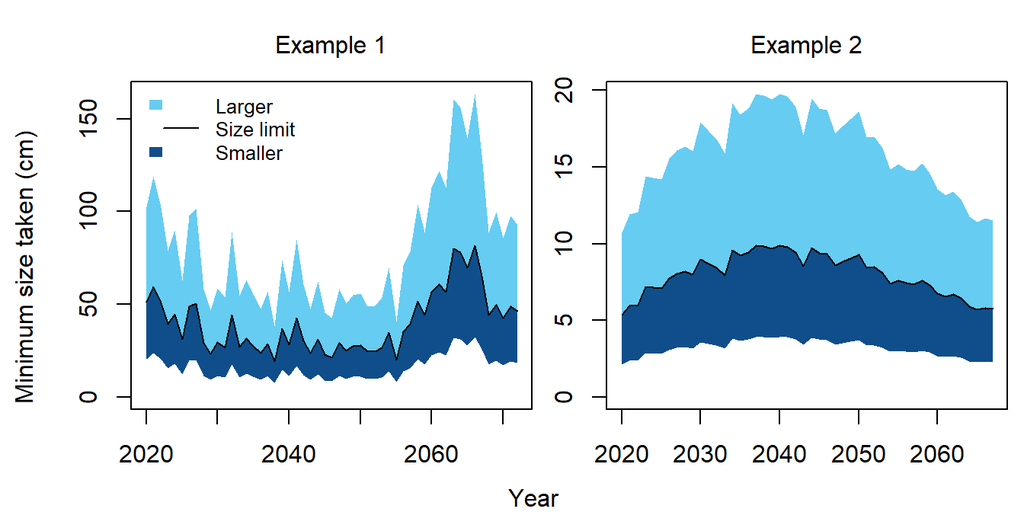

## Size limit implementation variability

| Answered |
| --- |
| Constant (V < 1%) |
| Not variable (1% < V < 5%) |
| Low variability (5% < V < 10%) |
| Variable (10% < V < 20%) |
| Highly variable (20% < V < 40%) |

| Justification |
| --- |
| No size limits |

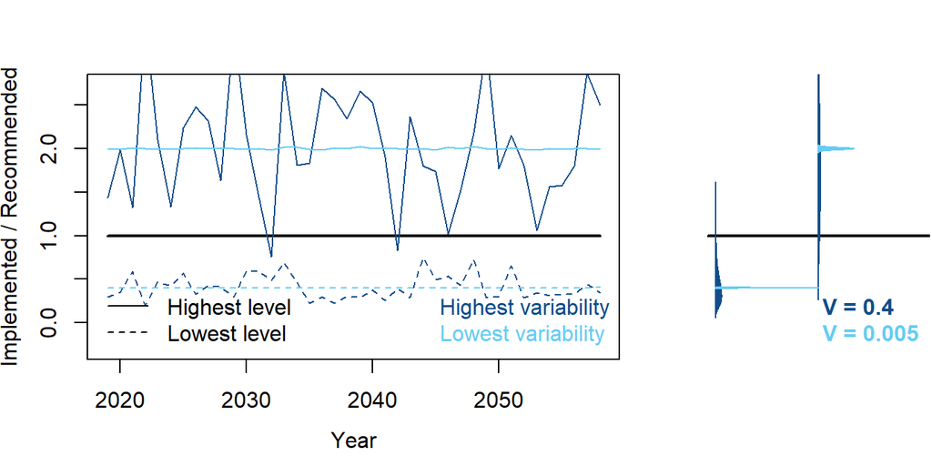

# Data Characteristics

## Available data types

| Answered |
| --- |
| Historical annual catches (from unfished) |
| Recent annual catches (at least 5 recent years) |
| Historical relative abundance index (from unfished) |
| Recent relative abundance index (at least 5 recent years) |
| Fishing effort |
| Size composition (length samples) |
| Age composition (age samples) |
| Growth (growth parameters) |
| Absolute biomass survey |

Justification

1. Provide the time series (specify years, if possible) that exist for catch, effort, and CPUE/abundance indices.  
Catch data are available from 1916  
Effort directed at herring (measured as commercial licenses) are available since 1976  
CPUE is not available; abundance index is a hydroacoustic survey conducted each year  
2. Describe how these data collected (e.g., log books, dealer reporting, observers).  
“Additionally tools such as port sampling, landing receipts, logbooks, and observer coverage are used to monitor catch and ensure vessels have the correct permits for the catch they are landing.” (Rapid Assessment Pacific Herring.pdf)  
3. Describe what types of sampling programs and methodologies exist for data collection, including the time-series of available sampling data and quality.  
Hydroacoustic surveys are conducted to create abundance estimates  
landing receipts are used to generate total catch  
Effort is based on purchased licenses  
Age composition based on research surveys conducted by California Department of Fish and Wildlife  
4. Describe all sources of uncertainty in the status, biology, life history and data sources of the fishery. Include links to documentation, reports.  
Growth, timing of maturity are all fairly well known. Biology when offshore is poorly understood, but that has little impact on management. Status also unknown because unfished abundance uncertain.  
“Currently the stock assessment for the San Francisco Pacific herring stock consists of spawning biomass estimates each year, which are used to set precautionary targets for harvest. Other reference points (unfished biomass, B0; biomass needed to obtain maximum sustainable yield, BMSY; and fishing mortality needed to obtain MSY, FMSY) are not available, and neither is an estimate of unfished age distribution.” (Seafood Watch Herring-Pacific-California.pdf)  
Annual uncertainty in productivity is acknowledged. Assessment models attempt to predict available biomass based on ocean conditions when setting quota. (https://nrm.dfg.ca.gov/FileHandler.ashx?DocumentID=148632&inline)

## Catch reporting bias

| Answered |
| --- |
| Strong under-reporting (30% - 50%) |
| Under-reporting (10% - 30%) |
| Slight under-reporting (0% - 10%) |
| Reported accurately (+/- 5%) |
| Slight over-reporting (less than 10%) |

| Justification |
| --- |
| Reporting is quite accurate. There are no concerns |

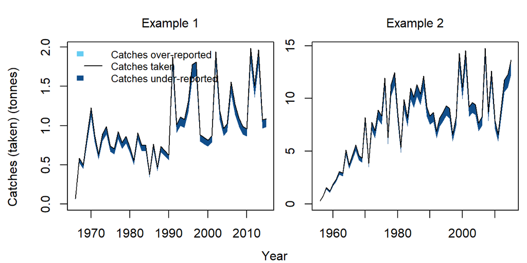

## Hyperstability in indices

| Answered |
| --- |
| Strong hyperdepletion (2 < Beta < 3) |
| Hyperdepletion (1.25 < Beta < 2) |
| Proportional (0.8 < Beta < 1.25) |
| Hyperstability (0.5 < Beta < 0.8) |
| Strong hyperstability (0.33 < Beta < 0.5) |

[output not shown]

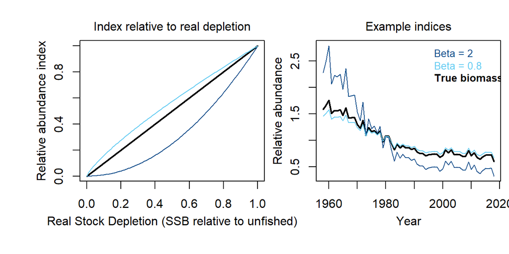

| Answered |
| --- |
| Perfect |
| Good (accurate and precise) |
| Data moderate (some what inaccurate and imprecise) |
| Data poor (inaccurate and imprecise) |

| Justification |
| --- |
| Annual catches are accurate; abundance is based on hydroacoustic and assumptions of how ocean conditions affect recruitment. Length/age compositions seem reasonable (though sample size is unknown). |

# Version Notes

The package is subject to ongoing testing. If you find a bug or a problem please send a report to t.carruthers@oceans.ubc.ca so that it can be fixed!

tcar_-2019-11-26-10:25:40

Open Source, GPL-2 2019